# R Notebook

## Context

As part of Reproducible Research course which is Mandatory course for 2nd year students of Data Science and Business Analytics, we are reproducing already existing project.

Link to the project: https://www.kaggle.com/code/alfiansyahachmad/walmart-sales-analysis-eda-and-econometrics

## Description

Walmart is an American multinational retail corporation that operates a chain of hypermarkets, discount department stores, and grocery stores from the United States, headquartered in Bentonville, Arkansas (Wikipedia).

In Retail Industry, sales is the most important metric in their business model that make profit. On this reason, sales analysis will be a good way in determining business operation.

In this below dataset We’ll reproduce the wxisting analysis how Walmart Sales looks like (Trend and Seasonal) and explain wether available feature (macroeconomic condition) would be affecting it using Econometric Panel Regression (Fixed Effect and Random Effect).

##All required libraries will be listed here

```r
library(readr)
library(dplyr)
library(ggplot2)
library(lubridate)
library(zoo)
library(scales)
library(tidyr)
```

##All required packages will be listed here

```r
install.packages("zoo")
```

```
Error in install.packages : Updating loaded packages
```

```r
install.packages("scales")
```

```
Error in install.packages : Updating loaded packages
```

```r
install.packages("ggpubr")
```

```
Error in install.packages : Updating loaded packages
```

##First we read the dataset

```r
url<-"https://raw.githubusercontent.com/WojciechMisiura/rr_project/main/Walmart_Store_sales.csv" #as we already added our dataset to github, we will read data directly from github

data<-read_csv(url)
head(data)
```

| Store | Date | Weekly_Sales | Holiday_Flag | Temperature | Fuel_Price | CPI | Unemployment |
| --- | --- | --- | --- | --- | --- | --- | --- |
| 1 | 05-02-2010 | 1643691 | 0 | 42.31 | 2.572 | 211.0964 | 8.106 |
| 1 | 12-02-2010 | 1641957 | 1 | 38.51 | 2.548 | 211.2422 | 8.106 |
| 1 | 19-02-2010 | 1611968 | 0 | 39.93 | 2.514 | 211.2891 | 8.106 |
| 1 | 26-02-2010 | 1409728 | 0 | 46.63 | 2.561 | 211.3196 | 8.106 |
| 1 | 05-03-2010 | 1554807 | 0 | 46.50 | 2.625 | 211.3501 | 8.106 |
| 1 | 12-03-2010 | 1439542 | 0 | 57.79 | 2.667 | 211.3806 | 8.106 |

```r
spec(data)
```

```r
names(data)
```

```r
colnames(data)
```

```r
str(data)
```

```r
summary(data)
```

```r
colSums(is.na(data))
```

```r
any(duplicated(data))
```

```r
data$Date <- as.Date(data$Date, format = "%d-%m-%Y")

data$Weekly_Sales <- round(data$Weekly_Sales / 1000, 3)
data$CPI <- round(data$CPI, 2)

data2 <- data

data2 <- data2[order(data2$Date), ]

panel <- data2 %>%
  group_by(Store, Date) %>%
  summarise(
    Weekly_Sales = mean(Weekly_Sales),
    Holiday_Flag = mean(Holiday_Flag),
    Temperature = mean(Temperature),
    Fuel_Price = mean(Fuel_Price),
    CPI = mean(CPI),
    Unemployment = mean(Unemployment),
    .groups = "drop"
  )

panel$Month <- month(panel$Date)
panel$Year <- year(panel$Date)

head(panel)
```

| Store | Date | Weekly_Sales | Holiday_Flag | Temperature | Fuel_Price | CPI | Unemployment | Month | Year |
| --- | --- | --- | --- | --- | --- | --- | --- | --- | --- |
| 1 | 2010-02-05 | 1643.691 | 0 | 42.31 | 2.572 | 211.10 | 8.106 | 2 | 2010 |
| 1 | 2010-02-12 | 1641.957 | 1 | 38.51 | 2.548 | 211.24 | 8.106 | 2 | 2010 |
| 1 | 2010-02-19 | 1611.968 | 0 | 39.93 | 2.514 | 211.29 | 8.106 | 2 | 2010 |
| 1 | 2010-02-26 | 1409.728 | 0 | 46.63 | 2.561 | 211.32 | 8.106 | 2 | 2010 |
| 1 | 2010-03-05 | 1554.807 | 0 | 46.50 | 2.625 | 211.35 | 8.106 | 3 | 2010 |
| 1 | 2010-03-12 | 1439.542 | 0 | 57.79 | 2.667 | 211.38 | 8.106 | 3 | 2010 |

```r
data_sub <- data[, !(names(data) %in% c('Month', 'Year', 'Store'))]

summary(data_sub)
```

```
      Date             Weekly_Sales     Holiday_Flag      Temperature       Fuel_Price
 Min.   :2010-02-05   Min.   : 210.0   Min.   :0.00000   Min.   : -2.06   Min.   :2.472
 1st Qu.:2010-10-08   1st Qu.: 553.4   1st Qu.:0.00000   1st Qu.: 47.46   1st Qu.:2.933
 Median :2011-06-17   Median : 960.7   Median :0.00000   Median : 62.67   Median :3.445
 Mean   :2011-06-17   Mean   :1047.0   Mean   :0.06993   Mean   : 60.66   Mean   :3.359
 3rd Qu.:2012-02-24   3rd Qu.:1420.2   3rd Qu.:0.00000   3rd Qu.: 74.94   3rd Qu.:3.735
 Max.   :2012-10-26   Max.   :3818.7   Max.   :1.00000   Max.   :100.14   Max.   :4.468
      CPI         Unemployment
 Min.   :126.1   Min.   : 3.879
 1st Qu.:131.7   1st Qu.: 6.891
 Median :182.6   Median : 7.874
 Mean   :171.6   Mean   : 7.999
 3rd Qu.:212.7   3rd Qu.: 8.622
 Max.   :227.2   Max.   :14.313
```

## A. Aggregate Time Series Analysis

How is the Walmart aggregate sales looks like? Does this sales has seasonal component? ## Below is the Aggregate Sales for the whole Walmart Store

```r
holiday_date <- as.Date(c('2010-02-12', '2010-09-10',
                          '2010-11-26', '2010-12-31',
                          '2011-02-11', '2011-09-09',
                          '2011-11-25', '2011-12-30',
                          '2012-02-10', '2012-09-07'))

locate <- as.Date('2011-05-06')

agg_sales <- aggregate(panel$Weekly_Sales, by = list(Date = panel$Date), FUN = sum)

ggplot(agg_sales, aes(x = Date, y = x)) +
  geom_line(color = "steelblue", size = 1) +
  geom_line(data = transform(agg_sales, x = rollmean(x, k = 12, fill = NA)),
            aes(x = Date, y = x), color = "firebrick", size = 1) +
  geom_vline(xintercept = as.numeric(holiday_date), color = "darkred", alpha = 0.2, linetype = "dashed") +
  labs(title = "Walmart Aggregate Sales Trend\n(In Thousand Dollars)",
       x = NULL, y = NULL) +
  theme_bw() +
  theme(plot.title = element_text(size = 20, face = "bold", hjust = 0.5),
        axis.text.x = element_text(angle = 45, vjust = 0.5, hjust = 1),
        axis.text.y = element_text(size = 12),
        axis.title = element_text(size = 14),
        panel.grid.major = element_blank(),
        panel.grid.minor = element_blank(),
        panel.border = element_blank(),
        panel.background = element_rect(fill = "white"),
        plot.margin = margin(20, 20, 20, 20, "pt"))
```

[output not shown]

## Below are the detail about sales in holiday, are thanksgiving holiday have highest sales?

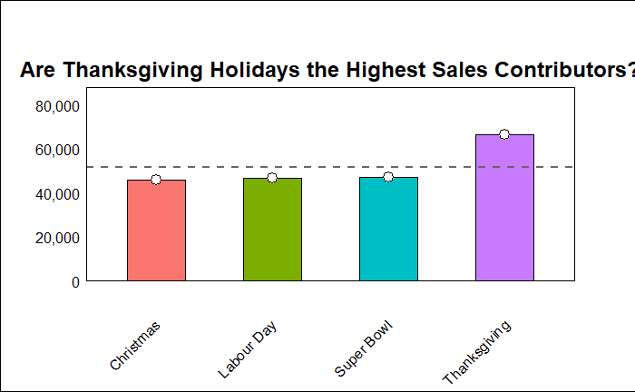

```r
super_bowl <- c('2010-02-12', '2011-02-11', '2012-02-10')
labour_day <- c('2010-09-10', '2011-09-09', '2012-09-07')
thanksgiving <- c('2010-11-26', '2011-11-25', '2012-11-23')
christmas <- c('2010-12-31', '2011-12-30', '2012-12-28')

super_bowl_sales <- sum(data$Weekly_Sales[data$Date == '2011-02-11'])
labour_day_sales <- sum(data$Weekly_Sales[data$Date == '2011-09-09'])
thanksgiving_sales <- sum(data$Weekly_Sales[data$Date == '2011-11-25'])
christmas_sales <- sum(data$Weekly_Sales[data$Date == '2011-12-30'])

holiday_sales <- data.frame(
  Holiday = c("Super Bowl", "Labour Day", "Thanksgiving", "Christmas"),
  Sales = c(super_bowl_sales, labour_day_sales, thanksgiving_sales, christmas_sales)
)

holiday_sales$Sales <- round(holiday_sales$Sales, 2)

ggplot(holiday_sales, aes(x = Holiday, y = Sales, fill = Holiday)) +
  geom_bar(stat = "identity", width = 0.5, color = "black") +
  geom_text(aes(label = paste0(Sales, "k")), vjust = -0.5, size = 8, fontface = "bold", color = "white") +
  labs(title = "Are Thanksgiving Holidays the Highest Sales Contributors?",
       x = NULL, y = NULL) +
  theme_minimal() +
  theme(axis.text.x = element_text(angle = 45, hjust = 1, vjust = 0.5, size = 12, color = "black"),
        axis.text.y = element_text(size = 12, color = "black"),
        axis.title = element_text(size = 14, color = "black", face = "bold"),
        panel.grid.major = element_blank(),
        panel.grid.minor = element_blank(),
        plot.title = element_text(size = 18, color = "black", face = "bold", hjust = 0.5),
        plot.caption = element_text(size = 10, color = "gray50", hjust = 1),
        plot.background = element_rect(fill = "white"),
        panel.border = element_rect(color = "black", fill = NA),
        axis.line = element_line(color = "black"),
        plot.margin = margin(50, 50, 30, 30)) +
  scale_y_continuous(labels = comma, expand = expansion(mult = c(0, 0.1))) +
  coord_cartesian(ylim = c(0, max(holiday_sales$Sales) * 1.2)) +
  annotate("text", x = holiday_sales$Holiday, y = holiday_sales$Sales,
           label = paste0(holiday_sales$Sales, "k"), vjust = -0.5, size = 6, fontface = "bold", color = "white") +
  geom_hline(yintercept = mean(holiday_sales$Sales), linetype = "dashed", color = "gray40", size = 1) +
  geom_point(aes(x = holiday_sales$Holiday, y = holiday_sales$Sales),
             shape = 21, fill = "white", color = "black", size = 4) +
  guides(fill = "none")
```

```r
pivot_table <- panel %>%
  group_by(Date) %>%
  summarize(Weekly_Sales = sum(Weekly_Sales),
            Temperature = mean(Temperature),
            Fuel_Price = mean(Fuel_Price),
            CPI = mean(CPI),
            Unemployment = mean(Unemployment)) %>%
  tidyr::separate(Date, into = c("Year", "Month", "Day"), sep = "-") %>%
  select(-Day)

head(pivot_table)
```

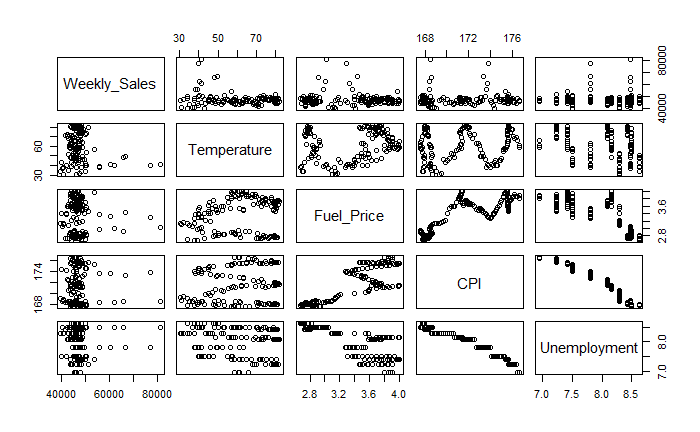

```r
pairplot <- pivot_table[, !(names(pivot_table) %in% c("Month", "Year"))]
pairs(pairplot)
```

```r
NA
NA
```

```r
cor_matrix <- cor(pivot_table[, !(names(pivot_table) %in% c("Month", "Year"))])
cor_matrix
```

```
             Weekly_Sales Temperature  Fuel_Price         CPI Unemployment
Weekly_Sales  1.000000000  -0.1591599 -0.05672248  0.02339266  0.003523566
Temperature  -0.159159882   1.0000000  0.20575698  0.15941497 -0.168459802
Fuel_Price   -0.056722483   0.2057570  1.00000000  0.82469284 -0.747204625
CPI           0.023392660   0.1594150  0.82469284  1.00000000 -0.977429167
Unemployment  0.003523566  -0.1684598 -0.74720463 -0.97742917  1.000000000
```

It seems that sales have less correlation with macroeconomic condition. Possible reason of this realtionship that because we use weekly data and macroeconomic variables like CPI, unemployment, fuel price have slow/rigid change in the short run.

[figure not shown]

```r
growth_df <- panel %>%
  select(Date, Weekly_Sales) %>%
  group_by(Date = as.yearmon(Date)) %>%
  summarize(Weekly_Sales = sum(Weekly_Sales)) %>%
  ungroup() %>%
  mutate(Rolling_Month = lag(Weekly_Sales),
         Growth_MoM = round((Weekly_Sales - Rolling_Month) / Rolling_Month * 100, 2))

growth_df <- growth_df %>%
  mutate(growth_df = lead(growth_df)) %>%
  select(-c(3, 4))

growth_df$Year <- year(growth_df$Date)
growth_df$Month <- month(growth_df$Date)

super_bowl <- c('2010-02-28', '2011-02-28', '2012-02-28')
labour_day <- c('2010-09-30', '2011-09-30', '2012-09-30')
thanksgiving <- c('2010-11-30', '2011-11-30', '2012-11-30')
christmas <- c('2010-12-31', '2011-12-31', '2012-12-31')

g2010 <- growth_df %>%
  filter(Year == 2010) %>%
  summarize(Month = Month[which.max(growth_df$Growth_MoM)], Growth_MoM = max(growth_df$Growth_MoM))

g2011 <- growth_df %>%
  filter(Year == 2011) %>%
  summarize(Month = Month[which.max(growth_df$Growth_MoM)], Growth_MoM = max(growth_df$Growth_MoM))

g2012 <- growth_df %>%
  filter(Year == 2012) %>%
  summarize(Month = Month[which.max(growth_df$Growth_MoM)], Growth_MoM = max(growth_df$Growth_MoM))





# Create a data frame with the text labels
text_labels <- data.frame(
  x = c(0.7, 0.2, 0.2, 0.75, 0.75, 0.75, 1.3, 1.3, 1.3),
  y = c(0.85, 0.5, 0.3, 0.5, 0.3, 0.1, 0.5, 0.3, 0.1),
  label = c("Highest Sales MoM Growth", "December", "42.35%", "December", "37.07%", "2011", "October", "27.46%", "2012"),
  #color = c("black", "blue", "gray", "blue", "gray", "gray", "blue", "gray", "gray"),
  #size = c(6, 12, 8, 12, 8, 8, 12, 8, 8),
  fontface = c("bold", "bold", "bold", "bold", "bold", "bold", "bold", "bold", "bold"),
  family = c("sans", "mono", "mono", "mono", "mono", "mono", "mono", "mono", "mono"),
  vjust = c(0, 0.5, 0.5, 0.5, 0.5, 0.5, 0.5, 0.5, 0.5),
  hjust = c(0.5, 0.5, 0.5, 0.5, 0.5, 0.5, 0.5, 0.5, 0.5)
)

# Create the plot
fig <- ggplot() +
  theme_void() +
  theme(plot.margin = margin(0, 0, 0, 0, "cm"))

# Add text elements to the plot
fig <- fig +
  geom_text(data = text_labels, aes(x = x, y = y, label = label,
                                    fontface = fontface, family = family, vjust = vjust, hjust = hjust))

# Show the plot
print(fig)
```

```r
NA
NA
NA
NA
```

Although Thanksgiving holiday on November has highest sales than the other holiday, December has the highest growth sales happening before Christmas in 2010 and 2011. It stated that in 2012, October become the highest MoM sales growth because we don’t have sales data on December 2012.